# PersonalMovement

D. Cucchiara

2022-06-14

# **Personal Movement Project**

## Reproducible Research Project 1

Data Loading and Pre-Processing:

```r
rawData <- read.csv("activity.csv", header=TRUE)
# examine the data set
head(rawData)
```

```
##   steps       date interval
## 1    NA 2012-10-01        0
## 2    NA 2012-10-01        5
## 3    NA 2012-10-01       10
## 4    NA 2012-10-01       15
## 5    NA 2012-10-01       20
## 6    NA 2012-10-01       25
```

```r
str(rawData)
```

```
## 'data.frame':    17568 obs. of  3 variables:
##  $ steps   : int  NA NA NA NA NA NA NA NA NA NA ...
##  $ date    : chr  "2012-10-01" "2012-10-01" "2012-10-01" "2012-10-01" ...
##  $ interval: int  0 5 10 15 20 25 30 35 40 45 ...
```

```r
dim(rawData)
```

```
## [1] 17568     3
```

```r
summary(rawData)
```

```
##      steps            date              interval
##  Min.   :  0.00   Length:17568       Min.   :   0.0
##  1st Qu.:  0.00   Class :character   1st Qu.: 588.8
##  Median :  0.00   Mode  :character   Median :1177.5
##  Mean   : 37.38                      Mean   :1177.5
##  3rd Qu.: 12.00                      3rd Qu.:1766.2
##  Max.   :806.00                      Max.   :2355.0
##  NA's   :2304
```

```r
head(rawData)
```

```
##   steps       date interval
## 1    NA 2012-10-01        0
## 2    NA 2012-10-01        5
## 3    NA 2012-10-01       10
## 4    NA 2012-10-01       15
## 5    NA 2012-10-01       20
## 6    NA 2012-10-01       25
```

Here, we could transform the date to POSIXct class if needed but it seems unnecessary.

## What is the mean total number of steps taken per day?

Calculate the total number of steps taken per day:

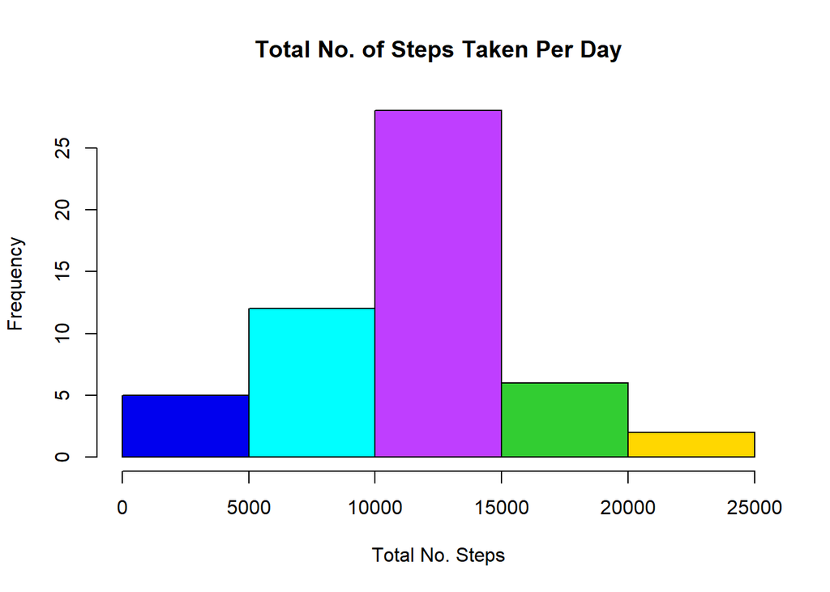

```r
steps <- aggregate(steps ~ date, data = rawData, sum)
# Create histogram
hist(steps$steps, main="Total No. of Steps Taken Per Day", xlab="Total No. Steps",
     ylab="Frequency", col=c("blue2", "cyan1", "darkorchid1", "limegreen", "gold1"))
```

Calculate the mean and median:

```r
# mean
mean(steps$steps, na.rm=TRUE)
```

```
## [1] 10766.19
```

```r
#median
median(steps$steps, na.rm=TRUE)
```

```
## [1] 10765
```

The mean number of steps taken per day is 10766.19. The median number of steps taken per day is 10765.

```r
head(steps)
```

```
##         date steps
## 1 2012-10-02   126
## 2 2012-10-03 11352
## 3 2012-10-04 12116
## 4 2012-10-05 13294
## 5 2012-10-06 15420
## 6 2012-10-07 11015
```

## What is the average daily activity pattern?

Make a time series plot of the 5-minute interval (x-axis) and the average number of steps taken, averaged across all days (y-axis)

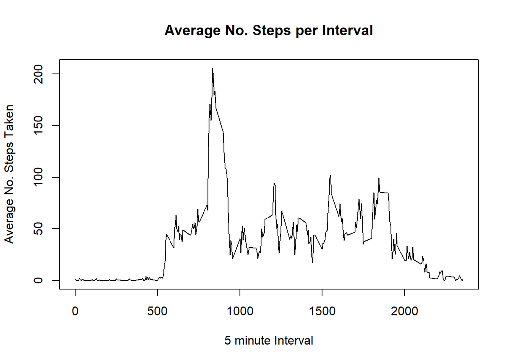

```r
# subset the data
stepsIntrv <- aggregate(steps~interval, data = rawData, mean, na.rm = TRUE)
#plot the time series
plot(stepsIntrv$interval, stepsIntrv$steps, type = "l",
     main = "Average No. Steps per Interval", xlab = "5 minute Interval",
     ylab = "Average No. Steps Taken")
```

Which 5-minute interval, on average across all the days in the dataset, contains the maximum number of steps?

```r
stepsIntrv[which.max(stepsIntrv[,2]),1]
```

```
## [1] 835
```

```r
head(stepsIntrv)
```

```
##   interval     steps
## 1        0 1.7169811
## 2        5 0.3396226
## 3       10 0.1320755
## 4       15 0.1509434
## 5       20 0.0754717
## 6       25 2.0943396
```

The maximum average steps occurred in interval 835.

## Imputing missing values

```r
# Calculate and report the total number of missing values in the dataset
numNas <- sum(is.na(rawData$steps))
# Find the mean
intvMean <- mean(stepsIntrv$steps)
numNas # get total NAs
```

```
## [1] 2304
```

```r
intvMean # get mean steps/interval
```

```
## [1] 37.3826
```

There are 2304 missing values in the data set.

Impute the missing values

```r
# Create a new dataset that is equal to the original dataset but
# with the missing data filled in
newSum <- rawData
newSum$steps[is.na(newSum$steps)] <- mean(rawData$steps, na.rm=TRUE)

head(newSum)
```

```
##     steps       date interval
## 1 37.3826 2012-10-01        0
## 2 37.3826 2012-10-01        5
## 3 37.3826 2012-10-01       10
## 4 37.3826 2012-10-01       15
## 5 37.3826 2012-10-01       20
## 6 37.3826 2012-10-01       25
```

Create histogram with new data and get mean and median

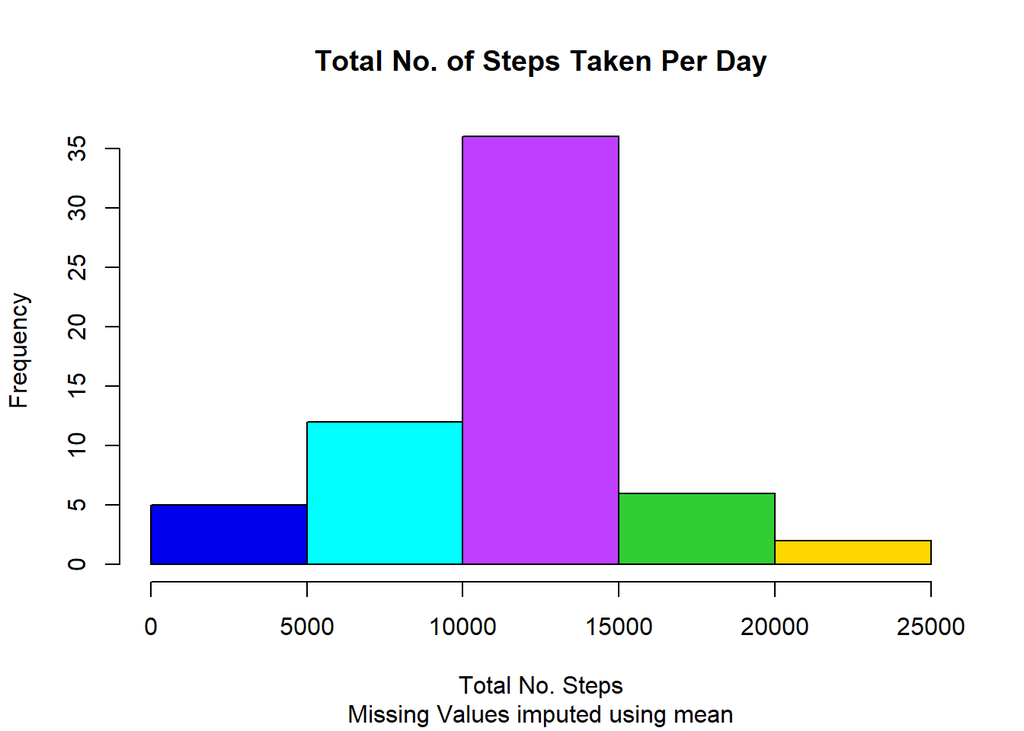

```r
# Make a histogram of the total number of steps taken each day
newSum1 <- aggregate(newSum$steps ~ newSum$date, FUN=sum)
colnames(newSum1) <- c("Date", "Steps")
hist(newSum1$Steps, main="Total No. of Steps Taken Per Day",
     sub="Missing Values imputed using mean",
     xlab="Total No. Steps", ylab="Frequency",
     col=c("blue2", "cyan1", "darkorchid1", "limegreen", "gold1"))
```

```r
# mean
mean(newSum1$Steps, na.rm=TRUE)
```

```
## [1] 10766.19
```

```r
#median
median(newSum1$Steps, na.rm=TRUE)
```

```
## [1] 10766.19
```

```r
# Examine new data
head(newSum1)
```

```
##         Date    Steps
## 1 2012-10-01 10766.19
## 2 2012-10-02   126.00
## 3 2012-10-03 11352.00
## 4 2012-10-04 12116.00
## 5 2012-10-05 13294.00
## 6 2012-10-06 15420.00
```

Do these values (mean and median) differ from the estimates from the first part of the assignment? *The mean is the same, The median in the raw data* *was 10765 and now it is also 10766.19.* *The median changed slightly.* What is the impact of imputing missing data on the estimates of the total daily number of steps? *very little impact.*

## Are there differences in activity patterns between weekdays and weekends?

Create a new factor variable in the dataset with two levels – “weekday” and “weekend” indicating whether a given date is a weekday or weekend day.

```r
newSum$DayType <- weekdays(as.Date(newSum$date))

newSum$DayType <- ifelse(newSum$DayType %in% c('Saturday','Sunday'),'Weekend','Weekday')

head(newSum)
```

```
##     steps       date interval DayType
## 1 37.3826 2012-10-01        0 Weekday
## 2 37.3826 2012-10-01        5 Weekday
## 3 37.3826 2012-10-01       10 Weekday
## 4 37.3826 2012-10-01       15 Weekday
## 5 37.3826 2012-10-01       20 Weekday
## 6 37.3826 2012-10-01       25 Weekday
```

```r
# Open necessary  packages
library(lattice)
library(plyr)
```

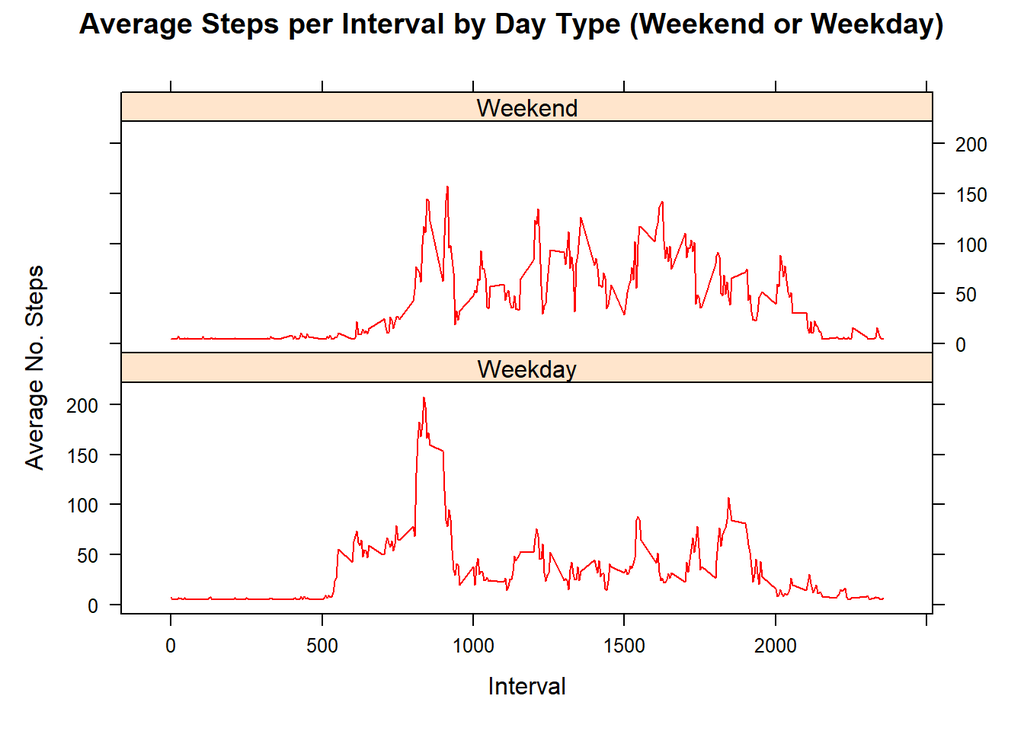

```r
# Get data make graph
newSumInt <- ddply(newSum, .(interval, DayType), summarize, avg = mean(steps))
xyplot(avg~interval|DayType, data=newSumInt, type="l", layout=c(1,2),
       main="Average Steps per Interval by Day Type (Weekend or Weekday)",
       xlab="Interval", ylab = "Average No. Steps", col="red")
```